# Eksploracja tekstu z R

A. M. Machno

## Text Mining

- Wydobywanie danych z teksu.
- Analiza danych wydobytych z tekstu.

Przykłady danych tekstowych:

- Pytania otwarte w ankietach.
- Wiadomości e-mail.
- Posty oraz komentarze na platformach społecznościowych oraz innych stronach internetowych.
- Artykuły prasowe, w szczególności komentarze giełdowe i polityczne.
- Teksty książek i sztuk teatralnych.

## Wydobywanie danych z tekstu

Analiza **bag-of-words**:

- Zlicza wystąpienia fraz (n-gramów) w analizowanych dokumentach.
- Nie bierze pod uwagę gramatyki.
- Nie bierze pod uwagę znaczenia słów.

Analiza emocjonalna (**sentiment analysis**):

- Zalicza frazę do kategorii emocjonalnej, przeważnie: pozytywna vs. negatywna.
- Bierze pod uwagę znaczenie fraz.
- Bierze pod uwagę kolejność fraz:
  - Słowa **very**, **greatly** itp. wzmacniają emocje następnego słowa.
  - Słowa **not**, **never** itp. zmieniają emocje

## Proces analizy tekstu

1. Postawienie problemu oraz wyznaczenie celów analizy.
2. Identyfikacja oraz zebranie odpowiednich danych.
3. Organizacja tekstu. Nadanie chronologii, dołączenie autorów itp.
4. **Wydobycie właściwości.**
5. Analiza danych.
6. Interpretacja wyników, postawienie rekomendacji, produkcja wyników (np. prognozy).

## Formaty danych tekstowych

- **Napis**: ciąg znaków stanowiący tekst ( zmienna typu *character*). Domyślny format, nienadający się do analizy.
- **Corpus**: Popularny format danych tekstowych, który poza tekstem przechowuje zadane metadane.
- *Document-Term-Matrix* (**DTM**): Macierz, której kolumny reprezentują analizowane frazy, wiersze reprezentują analizowane dokumenty. Współrzędne są liczbami wystąpień danych fraz w danych dokumentach.
- **Tidy text**: posiada kolumnę z identyfikatorem dokumentu oraz kolumnę z frazą występującą w tym dokumencie.

## Dane

```r
glimpse(data)
```

```
## Observations: 129,971
## Variables: 14
## $ X1                    <int> 0, 1, 2, 3, 4, 5, 6, 7, 8, 9, 10, 11, 12...
## $ country               <chr> "Italy", "Portugal", "US", "US", "US", "...
## $ description           <chr> "Aromas include tropical fruit, broom, b...
## $ designation           <chr> "Vulka Bianco", "Avidagos", NA, "Reserve...
## $ points                <int> 87, 87, 87, 87, 87, 87, 87, 87, 87, 87, ...
## $ price                 <dbl> NA, 15, 14, 13, 65, 15, 16, 24, 12, 27, ...
## $ province              <chr> "Sicily & Sardinia", "Douro", "Oregon", ...
## $ region_1              <chr> "Etna", NA, "Willamette Valley", "Lake M...
## $ region_2              <chr> NA, NA, "Willamette Valley", NA, "Willam...
## $ taster_name           <chr> "Kerin O’Keefe", "Roger Voss", "Paul Gre...
## $ taster_twitter_handle <chr> "@kerinokeefe", "@vossroger", "@paulgwin...
## $ title                 <chr> "Nicosia 2013 Vulka Bianco  (Etna)", "Qu...
## $ variety               <chr> "White Blend", "Portuguese Red", "Pinot ...
## $ winery                <chr> "Nicosia", "Quinta dos Avidagos", "Rains...
```

źródło: kaggle.com

## unnest_token

```r
library(tidytext)

data[1:5, ] %>% select(X1, description) %>%
  unnest_tokens(word, description)
```

```
## # A tibble: 166 x 2
##       X1      word
##    <int>     <chr>
##  1     0    aromas
##  2     0   include
##  3     0  tropical
##  4     0     fruit
##  5     0     broom
##  6     0 brimstone
##  7     0       and
##  8     0     dried
##  9     0      herb
## 10     0       the
## # ... with 156 more rows
```

## zdania

```r
data[1:5, ] %>% select(X1, description) %>%
  unnest_tokens(word, description, token = "sentences") %>% glimpse()
```

```
## Observations: 12
## Variables: 2
## $ X1   <int> 0, 0, 1, 1, 1, 2, 2, 2, 3, 3, 4, 4
## $ word <chr> "aromas include tropical fruit, broom, brimstone and drie...
```

## n-gramy

```r
data[1:5, ] %>% select(X1, description) %>%
  unnest_tokens(word, description, token = "ngrams", n = 2)
```

```
## # A tibble: 161 x 2
##       X1             word
##    <int>            <chr>
##  1     0   aromas include
##  2     0 include tropical
##  3     0   tropical fruit
##  4     0      fruit broom
##  5     0  broom brimstone
##  6     0    brimstone and
##  7     0        and dried
##  8     0       dried herb
##  9     0         herb the
## 10     0       the palate
## # ... with 151 more rows
```

## stop words

```r
stop_words
```

```
## # A tibble: 1,149 x 2
##           word lexicon
##          <chr>   <chr>
##  1           a   SMART
##  2         a's   SMART
##  3        able   SMART
##  4       about   SMART
##  5       above   SMART
##  6   according   SMART
##  7 accordingly   SMART
##  8      across   SMART
##  9    actually   SMART
## 10       after   SMART
## # ... with 1,139 more rows
```

## Badanie frekwencji słów

```r
# tworzymy dane tidy text
text_df <- data %>%
  select(X1, description) %>%
  unnest_tokens(word, description)

# zliczamy słowa we wszystkich opisach
count(text_df, word, sort = T)
```

```
## # A tibble: 33,467 x 2
##       word      n
##      <chr>  <int>
##  1     and 347897
##  2     the 221350
##  3       a 179909
##  4      of 173049
##  5    with 120514
##  6    this 114185
##  7      is  96816
##  8    wine  78322
##  9 flavors  62791
## 10      in  62522
## # ... with 33,457 more rows
```

## Frekwencja istotnych słów

```r
count(text_df %>%
        anti_join(stop_words),
      word,
      sort = T)
```

```
## # A tibble: 32,801 x 2
##       word     n
##      <chr> <int>
##  1    wine 78322
##  2 flavors 62791
##  3   fruit 49927
##  4  aromas 39639
##  5  palate 38437
##  6 acidity 34999
##  7  finish 34971
##  8 tannins 30877
##  9   drink 30318
## 10  cherry 29321
## # ... with 32,791 more rows
```

## Dodawanie elementów do stop words

```r
# słowa specyficzne dla win
my_stop_words <-
  rbind(stop_words,
        tibble(word = c("wine", "flavors", "aromas", "palate"),
            lexicon = "my"))

# modyfikujemy ramkę tidy text
text_df <-
  text_df %>% anti_join(my_stop_words)
```

## Najczęściej występujące słowa

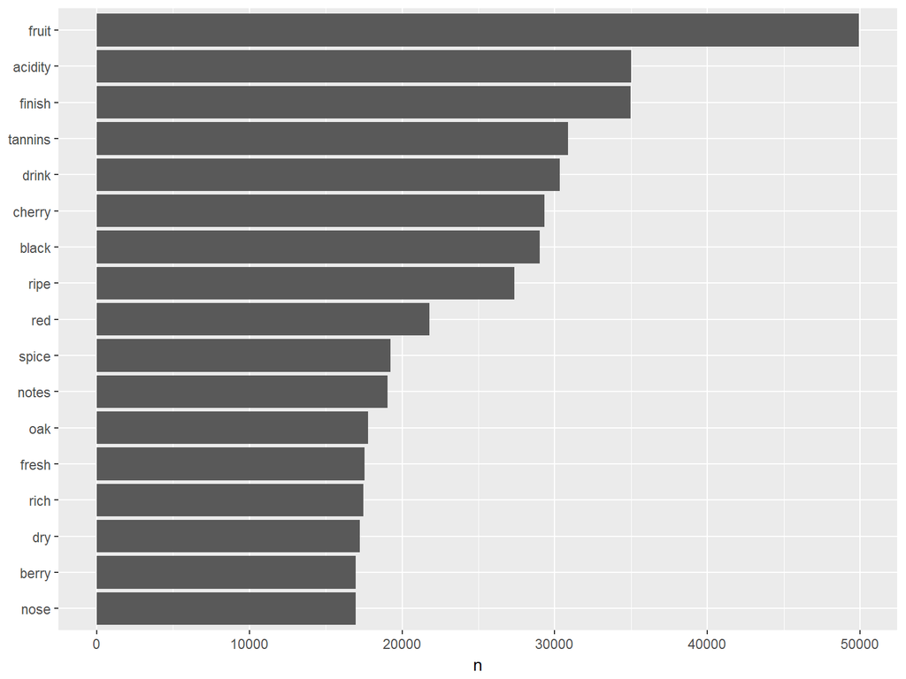

```r
text_df %>%
  count(word, sort = T) %>%
  filter(n > 15000) %>%
  mutate(word = reorder(word, n)) %>%
  ggplot(aes(x = word, y = n)) +
    geom_col() +
    xlab(NULL) +
    coord_flip()
```

## Ocena punktowa win

```r
#rozkład ilości punktów
summary(data$points)
```

```
##    Min. 1st Qu.  Median    Mean 3rd Qu.    Max.
##   80.00   86.00   88.00   88.45   91.00  100.00
```

```r
#tworzymy zmienną kategoryczną oceny
data <- data %>%
  mutate(quality = ifelse(points > 88, "good", "bad"))
```

## Najczęściej występujące słowa, a ocena

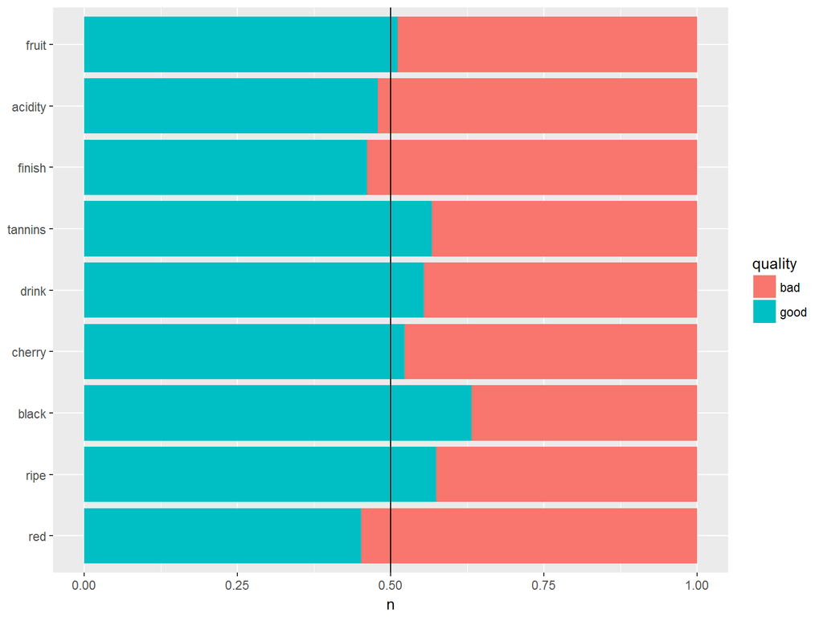

```r
text_df %>%
  left_join(data %>% select(X1, quality)) %>%
  count(quality, word, sort = T) %>%
  semi_join(text_df %>%
              count(word) %>%
              filter(n > 20000),
            by = "word") %>%
  mutate(word = reorder(word, n)) %>%
  ggplot(aes(x = word, y = n, fill = quality)) +
  geom_col(position = "fill") +
  geom_hline(yintercept = .5) +
  xlab(NULL) +
  coord_flip()
```

## Frekwencja słów, a jakość

```r
frequency <- text_df %>%
  left_join(data %>% select(X1, quality)) %>%
  count(quality, word) %>%
  group_by(quality) %>%
  mutate(proportion = n / sum(n)) %>%
  select(-n) %>%
  spread(key = quality, value = proportion, fill = 0)

glimpse(frequency)
```

```
## Observations: 32,797
## Variables: 3
## $ word <chr> "0", "0.4", "0.5", "0.53", "0.6", "0.7", "0.8", "01", "02...
## $ bad  <dbl> 0.000000e+00, 7.826753e-07, 7.826753e-07, 0.000000e+00, 7...
## $ good <dbl> 6.795981e-07, 2.038794e-06, 6.795981e-07, 6.795981e-07, 0...
```

## Wizualizacja frekwencji w zależności od jakości

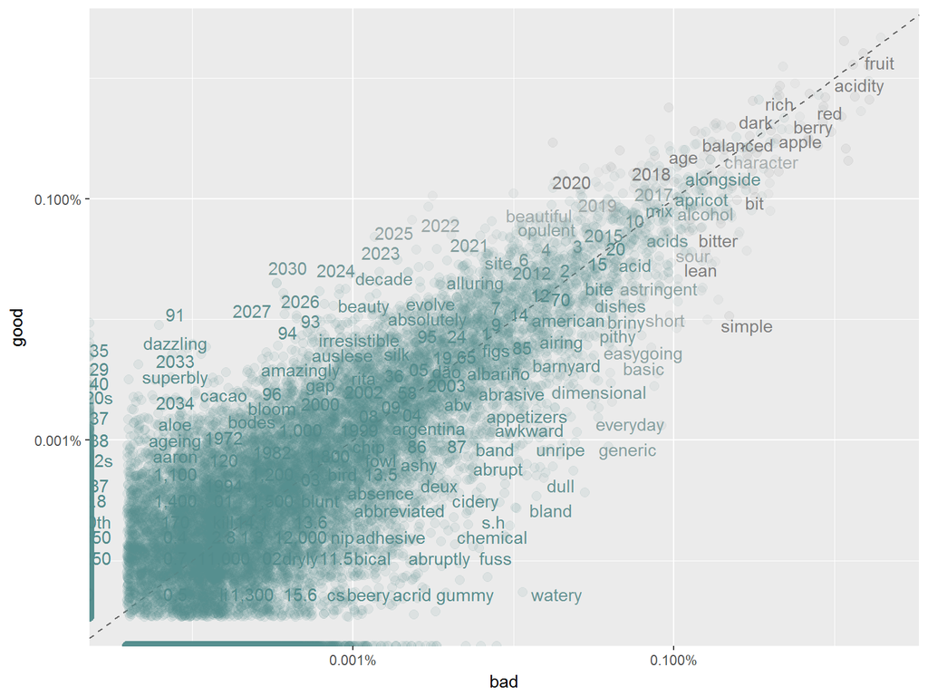

```r
ggplot(frequency, aes(x = bad,
                      y = good,
                      col = abs(bad - good))) +
  geom_abline(color = "gray40", lty = 2) +
  geom_jitter(alpha = 0.1, size = 2.5, width = 0.3, height = 0.3) +
  geom_text(aes(label = word), check_overlap = T, vjust = 1.5) +
  scale_x_log10(labels = percent_format()) +
  scale_y_log10(labels = percent_format()) +
  scale_color_gradient(limits = c(0, 0.001),
                       low = "darkslategray4",
                       high = "gray70") +
  theme(legend.position = "none")
```

## Ćwiczenie

Przeprowadzić analizę różnicy występowania słów w opisach w zależności od kraju pochodzenia wina. Proponuje podzielić kraje na 4 kategorie: *US*, *France*, *Italy*, *Other*.

## Słownik BING

```r
bing <- get_sentiments("bing")
bing
```

```
## # A tibble: 6,788 x 2
##           word sentiment
##          <chr>     <chr>
##  1     2-faced  negative
##  2     2-faces  negative
##  3          a+  positive
##  4    abnormal  negative
##  5     abolish  negative
##  6  abominable  negative
##  7  abominably  negative
##  8   abominate  negative
##  9 abomination  negative
## 10       abort  negative
## # ... with 6,778 more rows
```

## Słowa pozytywne oraz negatywne

```r
sentiment_df <-
  text_df %>%
  left_join(bing) %>%
  group_by(X1) %>%
  summarise(pos = sum(sentiment == "positive", na.rm = T),
            neg = sum(sentiment == "negative", na.rm = T),
            n = n())

glimpse(sentiment_df)
```

```
## Observations: 129,971
## Variables: 4
## $ X1  <int> 0, 1, 2, 3, 4, 5, 6, 7, 8, 9, 10, 11, 12, 13, 14, 15, 16, ...
## $ pos <int> 1, 1, 4, 2, 1, 3, 4, 2, 5, 3, 5, 1, 2, 1, 2, 6, 2, 1, 2, 2...
## $ neg <int> 1, 0, 0, 1, 2, 1, 0, 0, 0, 0, 0, 1, 0, 1, 0, 1, 1, 2, 2, 1...
## $ n   <int> 18, 15, 15, 19, 17, 22, 15, 10, 15, 14, 21, 14, 16, 19, 27...
```

## Związek polarności opisu z oceną wina

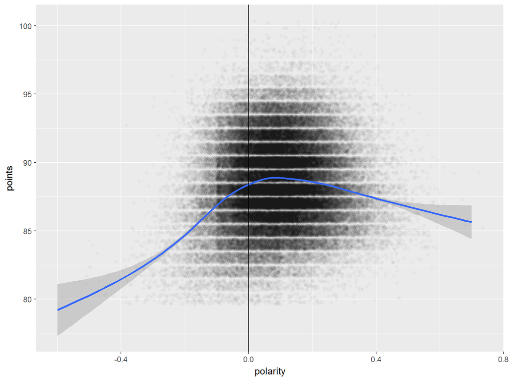

```r
data %>% left_join(sentiment_df, by = "X1") %>%
  mutate(polarity = (pos - neg) / n) %>%
  ggplot(aes(x = polarity, y = points)) +
  geom_jitter(alpha = 0.02, width = 0.1) +
  geom_smooth() +
  geom_vline(xintercept = 0)
```

## Związek pozytywnych i negatywnych emocji opisu z oceną wina

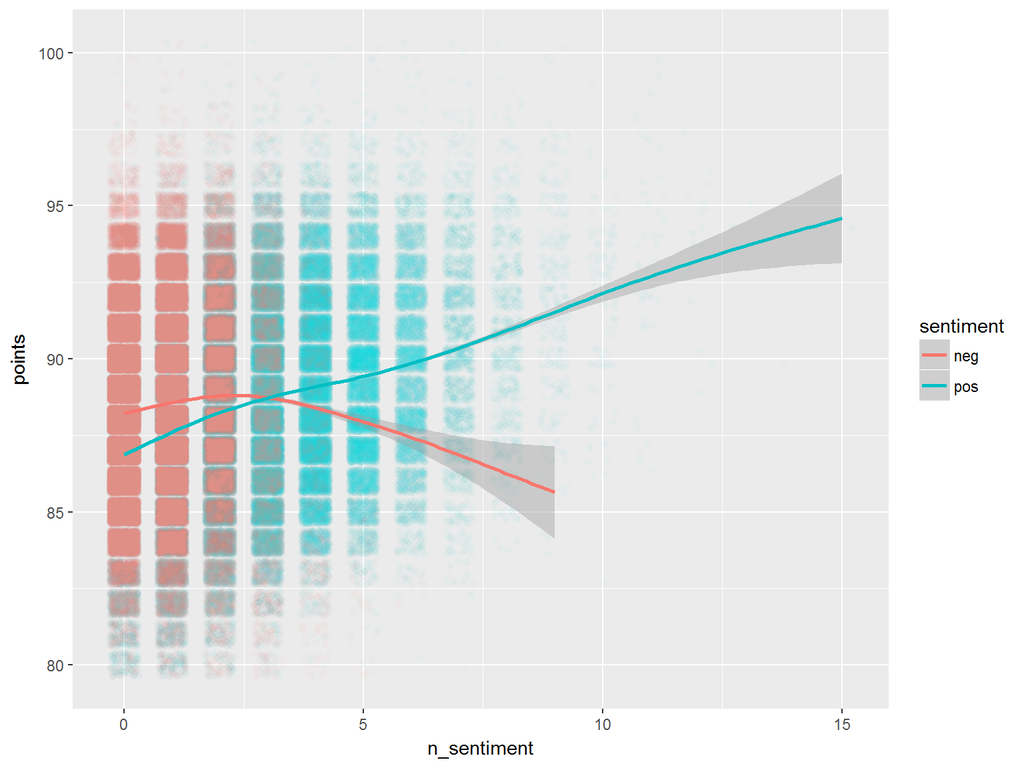

```r
data %>% left_join(sentiment_df, by = "X1") %>%
  gather(key = "sentiment", value = "n_sentiment", pos, neg) %>%
  ggplot(aes(x = n_sentiment, y = points, col = sentiment)) +
  geom_jitter(alpha = 0.02, width = 0.3) +
  geom_smooth()
```

## Związek pozytywnych i negatywnych emocji opisu z oceną wina. Wykresy pudełkowe.

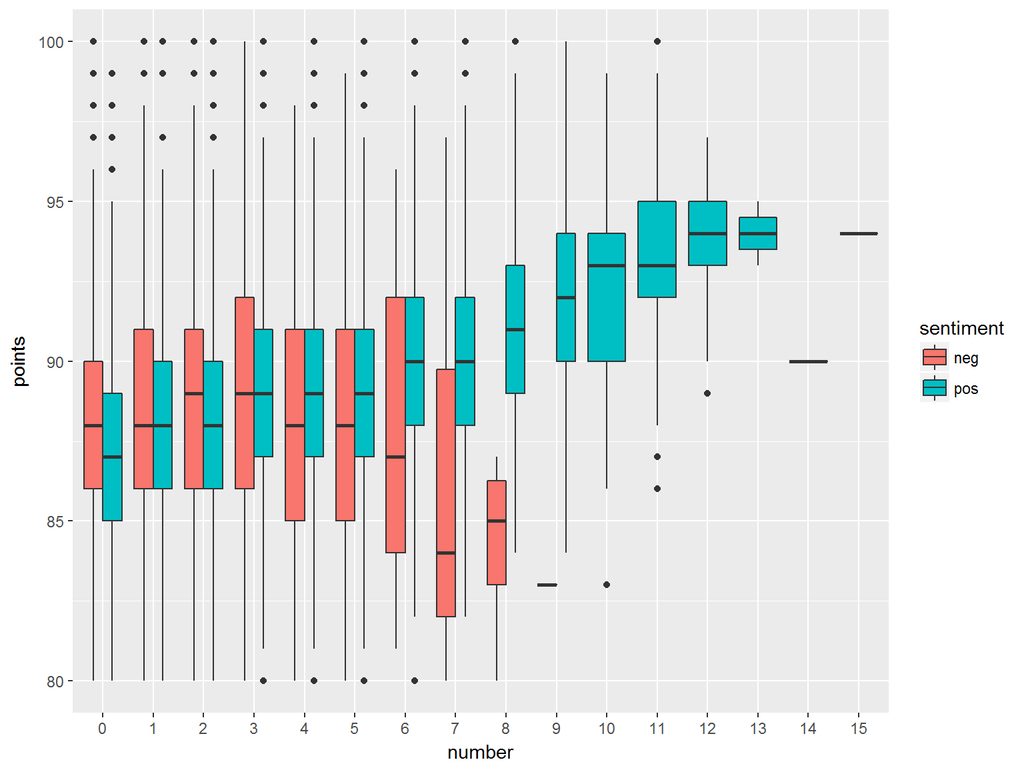

```r
data %>% left_join(sentiment_df, by = "X1") %>%
  gather(key = "sentiment", value = "n_sentiment", pos, neg) %>%
  ggplot(aes(x = factor(n_sentiment), y = points, fill = sentiment)) +
  geom_boxplot() +
  labs(x = "number")
```

## Czy najpopularnijesze słowa są pozytywne lub negatywne w kontekście wina?

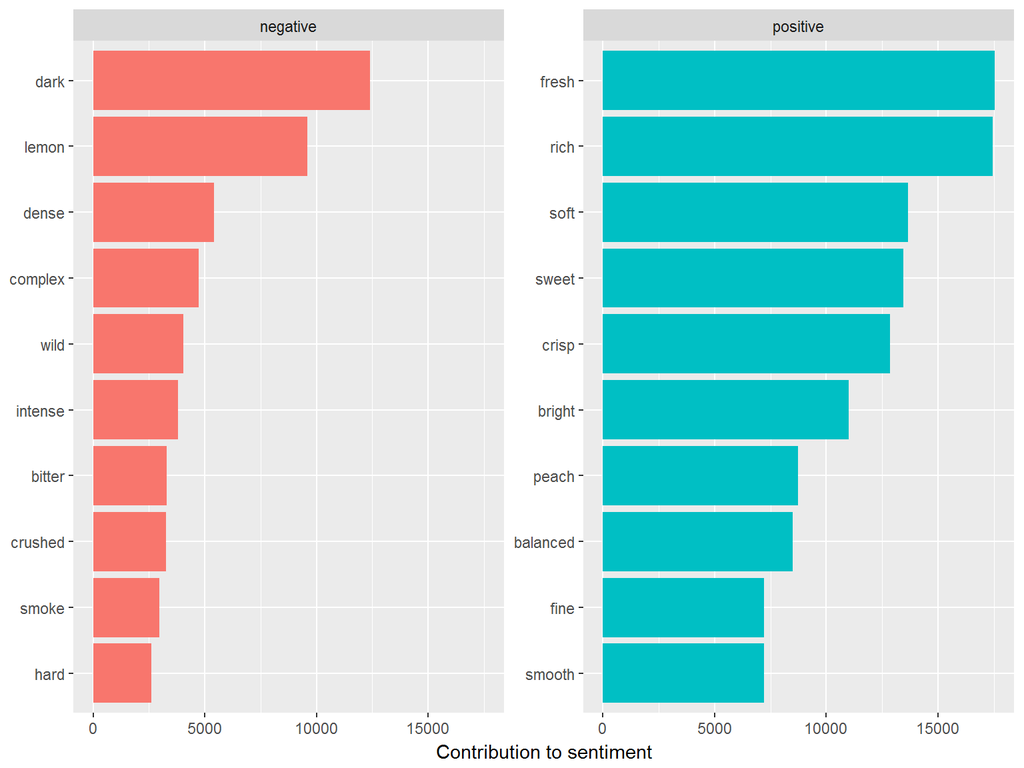

```r
text_df %>%
  inner_join(bing) %>%
  count(word, sentiment, sort = TRUE) %>%
  ungroup() %>%
  group_by(sentiment) %>%
  top_n(10) %>%
  ungroup() %>%
  mutate(word = reorder(word, n)) %>%
  ggplot(aes(word, n, fill = sentiment)) +
  geom_col(show.legend = FALSE) +
  facet_wrap(~sentiment, scales = "free_y") +
  labs(y = "Contribution to sentiment",
       x = NULL) +
  coord_flip()
```

## Chmura słów

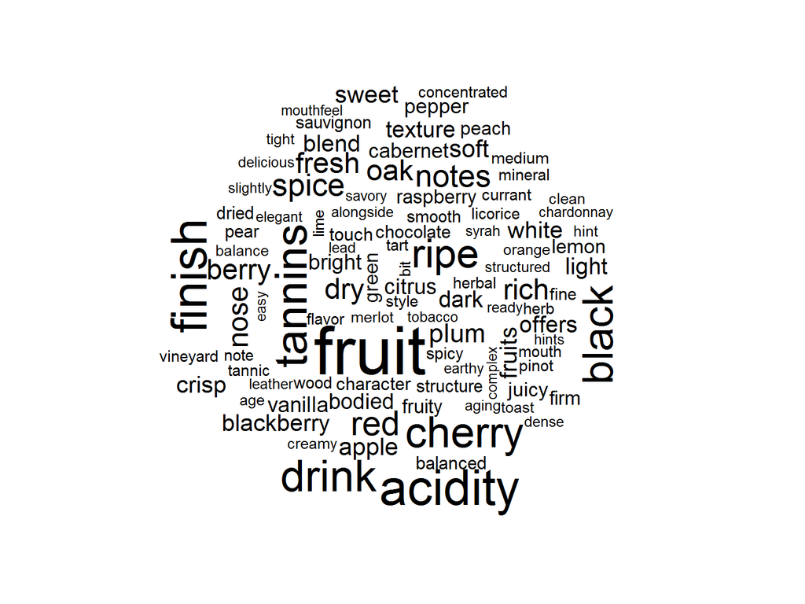

```r
library(wordcloud)

text_df %>%
  count(word) %>%
  with(wordcloud(word, n, max.words = 100))
```

## Chmura słów względem emocji

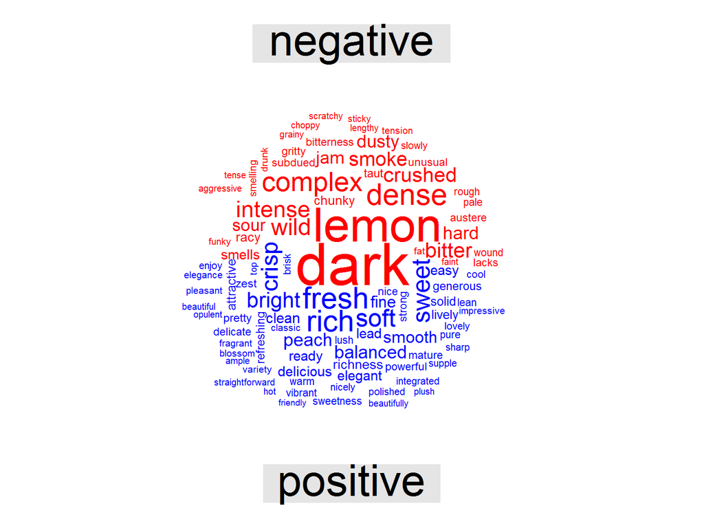

```r
text_df %>%
  inner_join(bing) %>%
  count(word, sentiment, sort = TRUE) %>%
  acast(word ~ sentiment, value.var = "n", fill = 0) %>%
  comparison.cloud(colors = c("red", "blue"),
                   max.words = 100)
```

## Słownik NRC

```r
nrc <- get_sentiments("nrc")
unique(nrc$sentiment)
```

```
##  [1] "trust"        "fear"         "negative"     "sadness"
##  [5] "anger"        "surprise"     "positive"     "disgust"
##  [9] "joy"          "anticipation"
```

```r
nrc
```

```
## # A tibble: 13,901 x 2
##           word sentiment
##          <chr>     <chr>
##  1      abacus     trust
##  2     abandon      fear
##  3     abandon  negative
##  4     abandon   sadness
##  5   abandoned     anger
##  6   abandoned      fear
##  7   abandoned  negative
##  8   abandoned   sadness
##  9 abandonment     anger
## 10 abandonment      fear
## # ... with 13,891 more rows
```

## Słowa emocjonalne.

```r
nrc_df <-
  text_df %>%
  left_join(nrc %>%
              filter(!(sentiment %in% c("positive", "negative")))) %>%
  group_by(X1, sentiment) %>%
  summarise(n = n()) %>%
  ungroup() %>%
  spread(key = sentiment, value = n, fill = 0) %>%
  select(X1:trust)

glimpse(nrc_df)
```

```
## Observations: 129,971
## Variables: 9
## $ X1           <int> 0, 1, 2, 3, 4, 5, 6, 7, 8, 9, 10, 11, 12, 13, 14,...
## $ anger        <dbl> 1, 0, 1, 0, 0, 0, 0, 0, 0, 0, 0, 0, 1, 0, 0, 0, 0...
## $ anticipation <dbl> 0, 0, 0, 1, 0, 1, 1, 0, 0, 0, 1, 0, 0, 1, 0, 1, 1...
## $ disgust      <dbl> 0, 0, 1, 1, 0, 0, 0, 0, 0, 0, 0, 0, 0, 0, 0, 0, 1...
## $ fear         <dbl> 1, 0, 1, 0, 0, 0, 0, 1, 0, 0, 0, 0, 1, 0, 0, 0, 1...
## $ joy          <dbl> 0, 0, 1, 1, 1, 2, 1, 1, 1, 0, 1, 1, 0, 1, 1, 0, 2...
## $ sadness      <dbl> 0, 0, 0, 0, 0, 1, 0, 0, 0, 0, 0, 0, 1, 0, 0, 0, 1...
## $ surprise     <dbl> 0, 0, 0, 0, 0, 2, 0, 0, 0, 0, 0, 0, 1, 1, 0, 0, 1...
## $ trust        <dbl> 2, 0, 2, 1, 1, 3, 1, 1, 0, 2, 2, 2, 1, 1, 1, 0, 4...
```

## Związek emocji opisu z oceną wina.

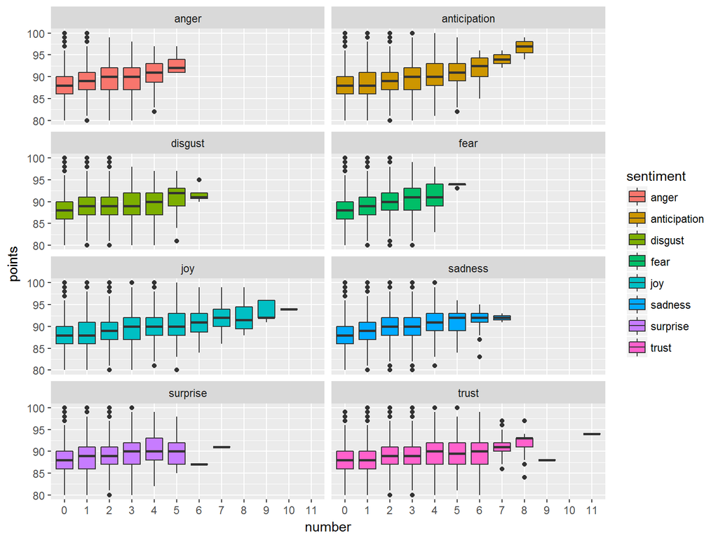

```r
data %>% left_join(nrc_df, by = "X1") %>%
  gather(key = "sentiment",
         value = "n_sentiment",
         anger:trust) %>%
  ggplot(aes(x = factor(n_sentiment),
             y = points,
             fill = sentiment)) +
  geom_boxplot() +
  labs(x = "number") +
  facet_wrap(~ sentiment, nrow = 4)
```

## Najpopularnijesze słowa emocjonalne w opisach win.

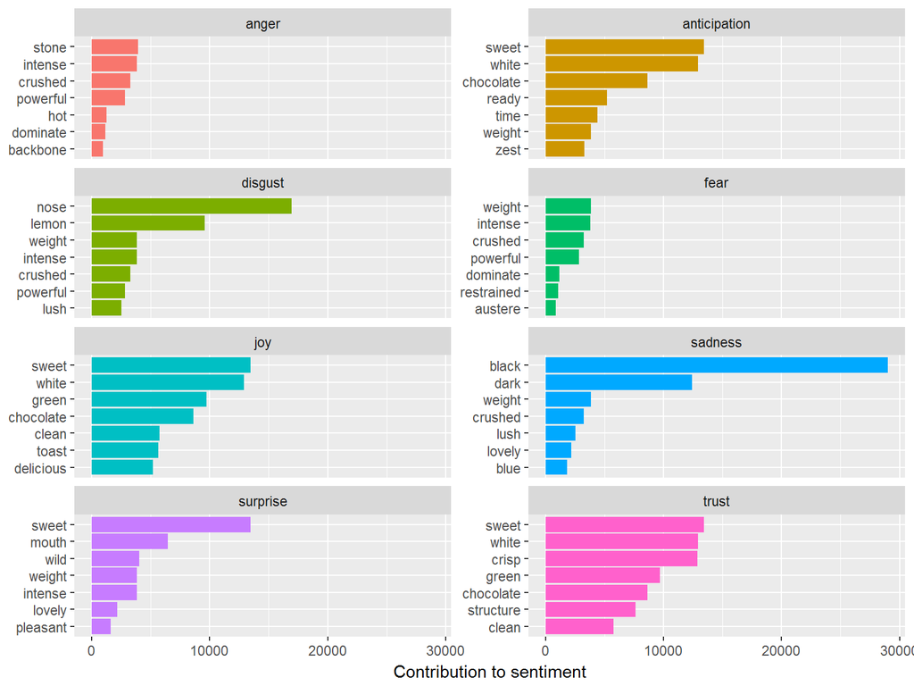

```r
text_df %>%
  inner_join(nrc %>%
              filter(!(sentiment %in% c("positive", "negative")))) %>%
  count(word, sentiment, sort = TRUE) %>%
  ungroup() %>%
  group_by(sentiment) %>%
  top_n(7) %>%
  ungroup() %>%
  mutate(word = reorder(word, n)) %>%
  ggplot(aes(word, n, fill = sentiment)) +
  geom_col(show.legend = FALSE) +
  facet_wrap(~sentiment, scales = "free_y",   ncol = 2) +
  labs(y = "Contribution to sentiment",
       x = NULL) +
  coord_flip()
```

## Ćwiczenie

Przeprowadzić analizę emocji w opisach win względem kraju pochodzenia. Proponuje podzielić kraje na 4 kategorie: *US*, *France*, *Italy*, *Other*.

## Literatura

1. Julia Silge and David Robinson, 2017, *Text Mining with R*, O’Reilly Media.
2. Bing Liu, 2015, *Sentiment Analysis: mining sentiments, opinions, and emotions*, Cambridge University Press.
3. Saif M. Mohammad, Svetlana Kiritchenko, and Xiaodan Zhu, 2013, *NRC-Canada: Building the State-of-the-Art in Sentiment Analysis of Tweets*, arXiv:1308.6242.